# Spatial Analysis

## Writing data

- shapefiles
- database connections
- use `st_write`

## Exercises

1. Load the Lake Tahoe shapefile (`data\h8_tahoe`). What is the `crs`? Plot the geometry.
2. Upload `boat-launch-sites.csv` and plot the geometry. Save it as a shapefile.

## Exercise 1

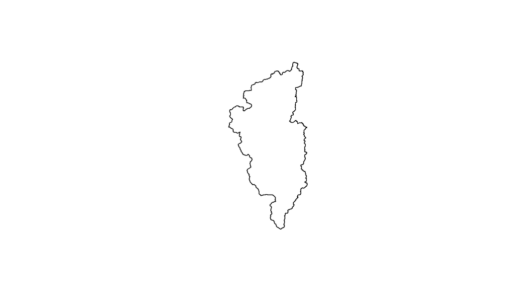

```r
tahoe <- read_sf(here("data", "h8_tahoe"))
st_crs(tahoe)
## Coordinate Reference System:
##   EPSG: 4326
##   proj4string: "+proj=longlat +datum=WGS84 +no_defs"
st_geometry(tahoe) %>% plot()
```

## Exercise 2

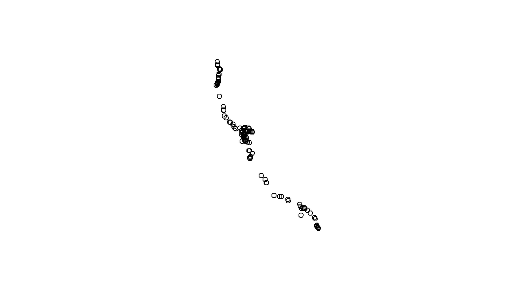

```r
boats <- read.csv(here("data", "boat-launch-sites.csv"))
boats_spatial <- st_as_sf(boats,
                       coords = c("lon", "lat"),
                       crs = 4326)
st_geometry(boats_spatial) %>% plot
```

## Exercise 2

```r
dir.create(here("data", "boat-launch-sites"))
st_write(boats_spatial, here("data", "boat-launch-sites", "boat-launch-sites.shp"))
## Writing layer `boat-launch-sites' to data source `C:/Users/Elizabeth Ng/Documents/GitHub/super-advanced-R/spatial-analysis/data/boat-launch-sites/boat-launch-sites.shp' using driver `ESRI Shapefile'
## features:       124
## fields:         4
## geometry type:  Point
```

## Geometric operations

## Types of geometric operations

Single

- logical predicates: (e.g., `is_valid`, `is_simple`)
- quantities: (`length`, `area`)
- dimensions: 0 = points, 1 = linear, 2 = surface
- derived geometries: `buffer`, `centroid`, `convex_hull` etc.

Pairs or sets

- predicates: `intersects`, `within`, `contains` etc.
- quantities: `distance`
- new geometries: `intersection`, `difference`, `union` etc.

## Methods for simple features

```r
methods(class = "sf")
##  [1] $<-                   [                     [[<-
##  [4] aggregate             anti_join             arrange
##  [7] as.data.frame         cbind                 coerce
## [10] dbDataType            dbWriteTable          distinct
## [13] filter                full_join             gather
## [16] group_by              group_map             group_split
## [19] identify              initialize            inner_join
## [22] left_join             merge                 mutate
## [25] nest                  plot                  print
## [28] rbind                 rename                right_join
## [31] sample_frac           sample_n              select
## [34] semi_join             separate              show
## [37] slice                 slotsFromS3           spread
## [40] st_agr                st_agr<-              st_area
## [43] st_as_sf              st_bbox               st_boundary
## [46] st_buffer             st_cast               st_centroid
## [49] st_collection_extract st_convex_hull        st_coordinates
## [52] st_crop               st_crs                st_crs<-
## [55] st_difference         st_geometry           st_geometry<-
## [58] st_interpolate_aw     st_intersection       st_intersects
## [61] st_is                 st_line_merge         st_nearest_points
## [64] st_node               st_normalize          st_point_on_surface
## [67] st_polygonize         st_precision          st_segmentize
## [70] st_set_precision      st_simplify           st_snap
## [73] st_sym_difference     st_transform          st_triangulate
## [76] st_union              st_voronoi            st_wrap_dateline
## [79] st_write              st_zm                 summarise
## [82] transmute             ungroup               unite
## [85] unnest
## see '?methods' for accessing help and source code
```

## Logical operations

```r
nc1 <- nc[1:5, ]
st_intersects(nc1, nc1, sparse = FALSE)
##       [,1]  [,2]  [,3]  [,4]  [,5]
## [1,]  TRUE  TRUE FALSE FALSE FALSE
## [2,]  TRUE  TRUE  TRUE FALSE FALSE
## [3,] FALSE  TRUE  TRUE FALSE FALSE
## [4,] FALSE FALSE FALSE  TRUE FALSE
## [5,] FALSE FALSE FALSE FALSE  TRUE
```

## Geometry generating operations

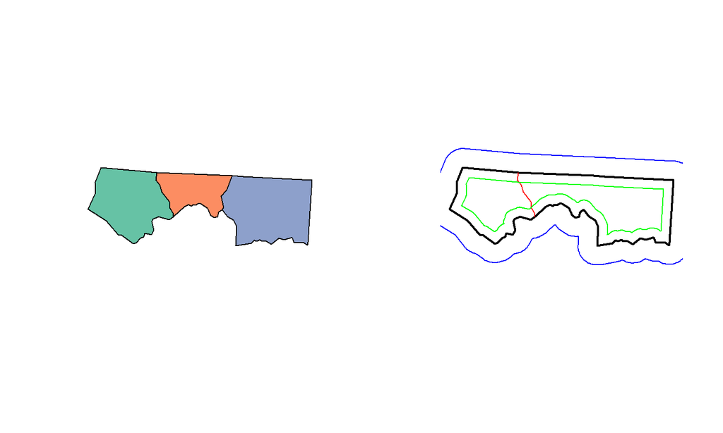

```r
opar <- par(mfrow = c(1,2))
ncg <- st_geometry(nc[1:3,])
plot(ncg, col = sf.colors(3, categorical = TRUE))

u <- st_union(ncg)
plot(u, lwd = 2)

plot(st_intersection(ncg[1], ncg[2]), col = 'red', add = TRUE) # border
plot(st_buffer(u, 10000), border = 'blue', add = TRUE)  # outer buffer
plot(st_buffer(u, -5000), border = 'green', add = TRUE) # inner buffer
```

## More complicated example

Where in North Carolina do four counties touch?

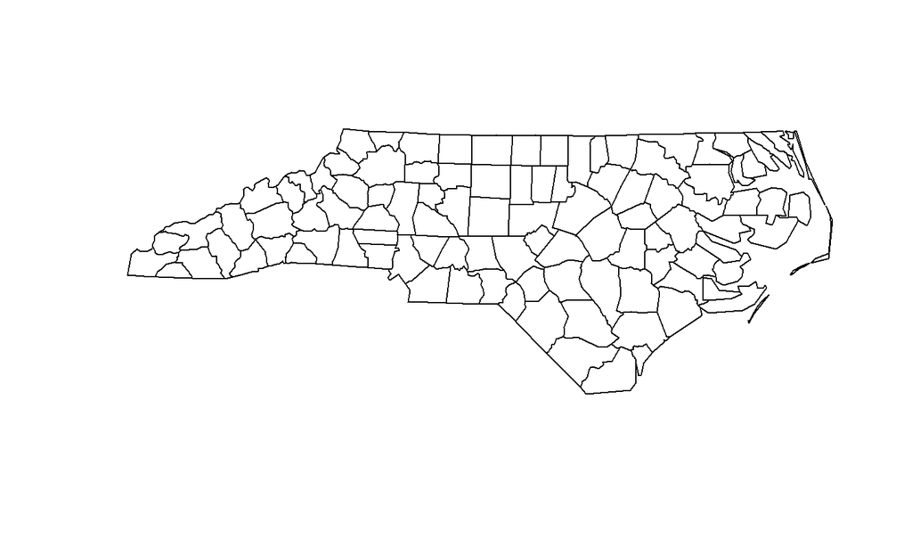

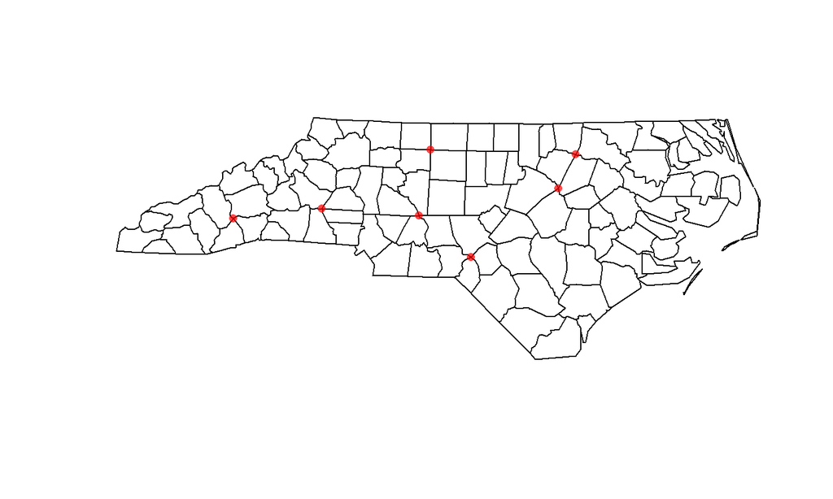

```r
pts <-  st_intersection(nc, nc)
## Warning: attribute variables are assumed to be spatially constant
## throughout all geometries
pts <- pts[st_dimension(pts) == 0, ] # dim of point intersection is 0
plot(st_geometry(nc))
plot(st_geometry(pts), add = TRUE, col = '#ff000044', pch = 16)
```

## Exercise

How many hot springs are near Lake Tahoe?

## Solution

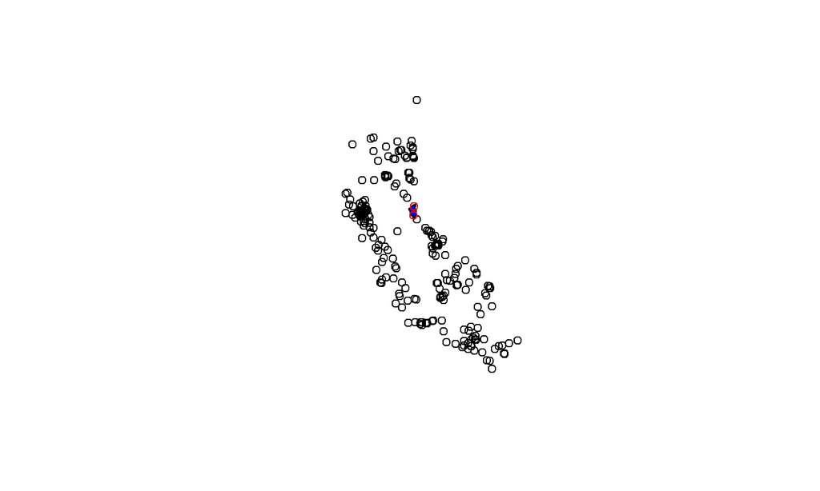

```r
hotsprings <- st_transform(hotsprings, 2228) # California zone 3
tahoe <- st_transform(tahoe, 2228)
tahoe_hotsprings <- st_intersection(tahoe, hotsprings)
## Warning: attribute variables are assumed to be spatially constant
## throughout all geometries

plot(st_geometry(hotsprings))
plot(st_geometry(tahoe), add = TRUE, col = "blue")
plot(st_geometry(tahoe_hotsprings), add = TRUE, col = "red")
```

## Making maps with `sf` and `ggplot2`

## Basics

- interfaces with `ggplot2` using `geom_sf`

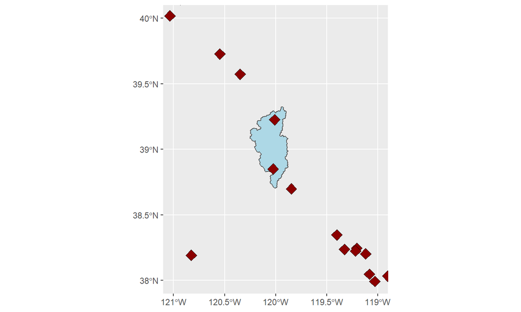

```r
ggplot() +
  geom_sf(data = tahoe, fill = "light blue") +
  geom_sf(data = hotsprings, size = 4, shape = 23, fill = "darkred") +
  coord_sf(xlim = c(-121, -119), ylim = c(38, 40))
```

## More complicated

[figure not shown]

[Timo Grossenbacher](https://timogrossenbacher.ch/2019/04/bivariate-maps-with-ggplot2-and-sf/)

## Exercise

Work through [this example from r-spatial](https://www.r-spatial.org/r/2018/10/25/ggplot2-sf.html)

## What about other types of data?

## `stars`

- support for raster and vector data cubes (arrays)
- support for long time series on vector data
- deal with data sets larger than local memory
- finished 2018 (??)
- more info [here](https://r-spatial.github.io/stars/)